# DV Assignment 2, Part 1: Which schools in a municipality are on track for reading and maths?

Group 6: Míra Sopuch, Kassandra Vroulli, Luna van Wonderen

2026-10-04

## Research question

**What is your research question?**

Which schools in a municipality are on track for reading and maths?

**Is it a question of analytics, inference or prediction?**

Analytics- the goal is to describe and compare school performance across a municipality and identify which schools are on track for maths and reading.

**Who is the target audience for your final visualization, and how does that shape your choices?**

The target audience could be a municipal education officer or a school board.

## Exploratory process

**Describe how you explored the data. Include at least one exploratory visualization below, and a short note on what it shows, and what you learned from it about your research question.**

```r
#Select relevant reference-level variables
count_cols <- c("REKENEN_LAGER1F", "REKENEN_1F", "REKENEN_1S",
                "LV_LAGER1F", "LV_1F", "LV_2F")

#Convert columns to numeric, and turn values like <5 to NA
#Clean reference-level counts
ref_levels <- referentieniveaus |>
  mutate(across(all_of(count_cols), ~ suppressWarnings(as.numeric(.)))) |>
  group_by(INSTELLINGSCODE) |>
  summarise(
    GEMEENTENAAM = first(GEMEENTENAAM),
    INSTELLINGSNAAM_VESTIGING = first(INSTELLINGSNAAM_VESTIGING),
    across(all_of(count_cols), ~ sum(.x, na.rm = TRUE)), .groups = "drop"
  ) |>
  mutate(
    #total number of students for maths and for reading
    rekenen_n = REKENEN_LAGER1F + REKENEN_1F + REKENEN_1S,
    reading_n = LV_LAGER1F + LV_1F + LV_2F,
    #percentage of students for each level
    math_1F = 100 * REKENEN_1F / rekenen_n,
    math_1S = 100 * REKENEN_1S / rekenen_n,
    reading_1F = 100 * LV_1F / reading_n,
    reading_2F = 100 * LV_2F / reading_n
  )

#calculate Schoolweging
school_weights <- schoolweging |>
  mutate(INSTELLINGSCODE = str_remove(OVT, "\\|.*$")) |>
  group_by(INSTELLINGSCODE) |>
  summarise(
    schoolweging = weighted.mean(schoolweging, w = aantal_leerlingen),
    .groups = "drop"
  )

#Combine reference-level results with schoolweging
school_data <- left_join(ref_levels, school_weights, by = "INSTELLINGSCODE")

#Amstelveen Gemeente
amstelveen_data <- filter(school_data, GEMEENTENAAM == "Amstelveen")

#Final data
amstelveen_data |>
  select(INSTELLINGSNAAM_VESTIGING, schoolweging,
         math_1F, math_1S, reading_1F, reading_2F)
```

```
## # A tibble: 20 × 6
##    INSTELLINGSNAAM_VESTIGING schoolweging math_1F math_1S reading_1F reading_2F
##    <chr>                            <dbl>   <dbl>   <dbl>      <dbl>      <dbl>
##  1 Brede School Omnibus              30.5    29.4    70.6      35.3        64.7
##  2 Basisschool Parcival              25.1    34.8    65.2       0         100
##  3 Roelof Venemaschool               22.5    34.1    65.9       8.43       91.6
##  4 Horizon                           33.3    75      25        28.6        71.4
##  5 De Cirkel                         27.3    47.3    34.5      27.3        72.7
##  6 Het Palet                         27.2    51.9    48.1       0         100
##  7 Willem Alexanderschool            25.3    35.7    64.3      12.3        87.7
##  8 Obs Michiel de Ruyter             24.7    34.5    65.5      23.6        76.4
##  9 Obs Piet Hein                     23.4    27.0    73.0       8.11       91.9
## 10 Mio Mondo                         25.6    48.8    51.2      17.1        82.9
## 11 Kindercampus King                 28.1    30      70         0         100
## 12 Obs de Linde                      26.2    55.6    44.4      28.6        71.4
## 13 Obs de Pioniers                   30.4    33.3    53.3      27.3        72.7
## 14 De Akker                          29.5    64.3    35.7       0         100
## 15 Triangel                          24.2    27.5    72.5       0         100
## 16 OBS de Westwijzer                 27.6    34.0    66.0      18.8        81.2
## 17 Karel Eykman school               24.7    39.2    60.8      11.4        88.6
## 18 Rembrandt                         22.5    22.6    77.4       0         100
## 19 School of Understanding           26.5    27.3    72.7       0         100
## 20 Elif Amstelveen                   33.9   100       0         0         100
```

```r
# National benchmark
national <- referentieniveaus |>
  mutate(across(all_of(count_cols), ~ suppressWarnings(as.numeric(.)))) |>
  group_by(INSTELLINGSCODE) |>
  summarise(across(all_of(count_cols), ~ sum(.x, na.rm = TRUE)),
            .groups = "drop") |>
  mutate(math_n = REKENEN_LAGER1F + REKENEN_1F + REKENEN_1S,
         reading_n = LV_LAGER1F + LV_1F + LV_2F) |>
  summarise(
    math_n = sum(math_n, na.rm = TRUE),
    reading_n = sum(reading_n, na.rm = TRUE),
    math_1F = 100 * sum(REKENEN_1F, na.rm = TRUE) / math_n,
    math_1S = 100 * sum(REKENEN_1S, na.rm = TRUE) / math_n,
    reading_1F = 100 * sum(LV_1F, na.rm = TRUE) / reading_n,
    reading_2F = 100 * sum(LV_2F, na.rm = TRUE) / reading_n
  )

national
```

```
## # A tibble: 1 × 6
##   math_n reading_n math_1F math_1S reading_1F reading_2F
##    <dbl>     <dbl>   <dbl>   <dbl>      <dbl>      <dbl>
## 1 150393    154130    52.3    44.8       22.9       77.0
```

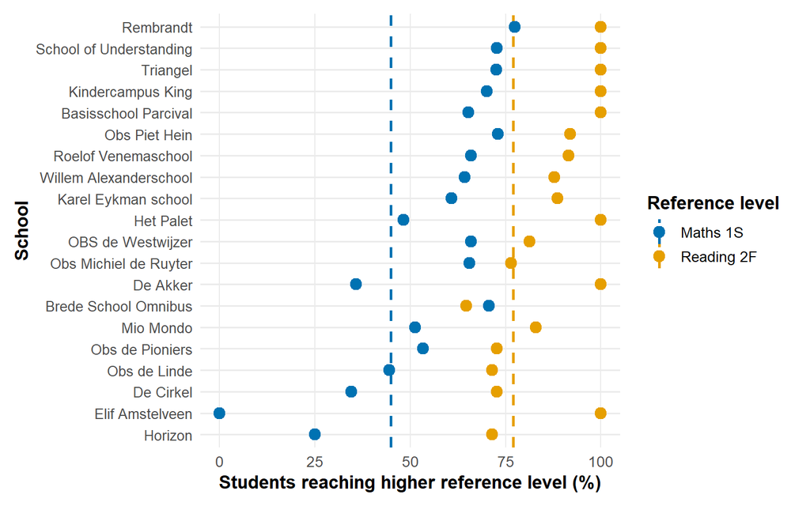

```r
plot_data <- amstelveen_data |>
  select(
    INSTELLINGSNAAM_VESTIGING,
    math_1S,
    reading_2F
  ) |>
  pivot_longer(
    cols = c(math_1S, reading_2F),
    names_to = "level",
    values_to = "percentage"
  )

national_plot <- tibble(
  level = c("math_1S", "reading_2F"),
  benchmark = c(
    national$math_1S,
    national$reading_2F
  )
)

ggplot(
  plot_data,
  aes(x = percentage,
      y = reorder(INSTELLINGSNAAM_VESTIGING, percentage),
      colour = level)
) +
  geom_vline(data = national_plot,
             aes(xintercept = benchmark, colour = level),
             linetype = "dashed", linewidth = 0.9) +
  geom_point(size = 3.5) +
  scale_colour_manual(
    values = c("math_1S" = "#0072B2", "reading_2F" = "#E69F00"),
    labels = c("math_1S" = "Maths 1S", "reading_2F" = "Reading 2F")
  ) +
  labs(x = "Students reaching higher reference level (%)", y = "School",
       colour = "Reference level") +
  theme_minimal(base_size = 13) +
  theme(legend.position = "right", legend.title = element_text(face = "bold"),
        axis.title = element_text(face = "bold"),
        panel.grid.minor = element_blank(),
        panel.grid.major.x = element_line(linewidth = 0.4),
        axis.text.y = element_text(size = 10),
        plot.margin = margin(10, 15, 10, 10))
```

```r
scatterplot_data <- amstelveen_data |>
  select(INSTELLINGSNAAM_VESTIGING, schoolweging, math_1S, reading_2F) |>
  pivot_longer(
    cols = c(math_1S, reading_2F),
    names_to = "level",
    values_to = "percentage"
  )

scatter_interactive <- ggplot(
  scatterplot_data,
  aes(schoolweging,
      percentage,
      colour = level)
) +
  geom_point(aes(
    text = paste0(
      "<b>", INSTELLINGSNAAM_VESTIGING, "</b>",
      "<br>", round(percentage, 2), "% reaching target level",
      "<br>School weighting: ", round(schoolweging, 2)
    )
  )
  ) +
  geom_smooth(method = "lm", se = FALSE, alpha = 0.1) +
  scale_colour_manual(
    values = c("math_1S" = "#0072B2", "reading_2F" = "#E69F00")
  ) +
  labs(
    title = "% of Students Reaching Higher Reference Level by School Weighting",
    x = "School weighting (higher = more disadvantaged)",
    y = "Percentage",
    colour = "Level"
  ) +
  theme_bw()

ggplotly(scatter_interactive, tooltip = "text")
```

[interactive chart not shown]

The above plot displays the percentage of students reaching the higher reference level by school weighting and subject. More students reach the target level in reading (yellow) than in math (blue), and students from more disadvantaged schools perform worse.

**Before submitting:** run the lintr check on this file, knit it, and push your work to GitHub.

#run lint(rstudioapi::getSourceEditorContext()$path)